# R Notebook

Load libraries

```r
library(tidyverse)
library(janitor)
library(CodeClanData)
```

View data

```r
game_sales
```

| name | genre | year_of_release | publisher | sales | critic_score | user_score | developer | rating | platform |
| --- | --- | --- | --- | --- | --- | --- | --- | --- | --- |
| Wii Sports | Sports | 2006 | Nintendo | 82.53 | 76 | 8.0 | Nintendo | E | Wii |
| Mario Kart Wii | Racing | 2008 | Nintendo | 35.52 | 82 | 8.3 | Nintendo | E | Wii |
| Wii Sports Resort | Sports | 2009 | Nintendo | 32.77 | 80 | 8.0 | Nintendo | E | Wii |
| New Super Mario Bros. | Platform | 2006 | Nintendo | 29.80 | 89 | 8.5 | Nintendo | E | DS |
| Wii Play | Misc | 2006 | Nintendo | 28.92 | 58 | 6.6 | Nintendo | E | Wii |
| New Super Mario Bros. Wii | Platform | 2009 | Nintendo | 28.32 | 87 | 8.4 | Nintendo | E | Wii |
| Mario Kart DS | Racing | 2005 | Nintendo | 23.21 | 91 | 8.6 | Nintendo | E | DS |
| Wii Fit | Sports | 2007 | Nintendo | 22.70 | 80 | 7.7 | Nintendo | E | Wii |
| Wii Fit Plus | Sports | 2009 | Nintendo | 21.79 | 80 | 7.4 | Nintendo | E | Wii |
| Brain Age: Train Your Brain in Minutes a Day | Misc | 2005 | Nintendo | 20.15 | 77 | 7.9 | Nintendo | E | DS |

[output cut: 990 more lines]

Short description of tibble

```r
str(game_sales)
```

```
spec_tbl_df [1,823 x 10] (S3: spec_tbl_df/tbl_df/tbl/data.frame)
 $ name           : chr [1:1823] "Wii Sports" "Mario Kart Wii" "Wii Sports Resort" "New Super Mario Bros." ...
 $ genre          : chr [1:1823] "Sports" "Racing" "Sports" "Platform" ...
 $ year_of_release: num [1:1823] 2006 2008 2009 2006 2006 ...
 $ publisher      : chr [1:1823] "Nintendo" "Nintendo" "Nintendo" "Nintendo" ...
 $ sales          : num [1:1823] 82.5 35.5 32.8 29.8 28.9 ...
 $ critic_score   : num [1:1823] 76 82 80 89 58 87 91 80 80 77 ...
 $ user_score     : num [1:1823] 8 8.3 8 8.5 6.6 8.4 8.6 7.7 7.4 7.9 ...
 $ developer      : chr [1:1823] "Nintendo" "Nintendo" "Nintendo" "Nintendo" ...
 $ rating         : chr [1:1823] "E" "E" "E" "E" ...
 $ platform       : chr [1:1823] "Wii" "Wii" "Wii" "DS" ...
 - attr(*, "spec")=
  .. cols(
  ..   name = col_character(),
  ..   genre = col_character(),
  ..   year_of_release = col_double(),
  ..   publisher = col_character(),
  ..   sales = col_double(),
  ..   critic_score = col_double(),
  ..   user_score = col_double(),
  ..   developer = col_character(),
  ..   rating = col_character(),
  ..   platform = col_character()
  .. )
 - attr(*, "problems")=<externalptr>
```

```r
glimpse(game_sales)
```

```
Rows: 1,823
Columns: 10
$ name            <chr> "Wii Sports", "Mario Kart Wii", "Wii Sports Resort", "New Super Mario Bros.", "Wii Play", "New Super M~
$ genre           <chr> "Sports", "Racing", "Sports", "Platform", "Misc", "Platform", "Racing", "Sports", "Sports", "Misc", "P~
$ year_of_release <dbl> 2006, 2008, 2009, 2006, 2006, 2009, 2005, 2007, 2009, 2005, 2005, 2005, 2007, 2011, 2011, 2012, 2010, ~
$ publisher       <chr> "Nintendo", "Nintendo", "Nintendo", "Nintendo", "Nintendo", "Nintendo", "Nintendo", "Nintendo", "Ninte~
$ sales           <dbl> 82.53, 35.52, 32.77, 29.80, 28.92, 28.32, 23.21, 22.70, 21.79, 20.15, 15.29, 12.13, 11.35, 10.81, 10.1~
$ critic_score    <dbl> 76, 82, 80, 89, 58, 87, 91, 80, 80, 77, 77, 86, 97, 90, 74, 78, 74, 88, 82, 88, 85, 97, 84, 85, 49, 85~
$ user_score      <dbl> 8.0, 8.3, 8.0, 8.5, 6.6, 8.4, 8.6, 7.7, 7.4, 7.9, 7.1, 8.7, 8.9, 8.4, 7.8, 7.2, 7.3, 8.7, 4.3, 6.6, 5.~
$ developer       <chr> "Nintendo", "Nintendo", "Nintendo", "Nintendo", "Nintendo", "Nintendo", "Nintendo", "Nintendo", "Ninte~
$ rating          <chr> "E", "E", "E", "E", "E", "E", "E", "E", "E", "E", "E", "E", "E", "E", "E10+", "E", "E10+", "E", "E", "~
$ platform        <chr> "Wii", "Wii", "Wii", "DS", "Wii", "Wii", "DS", "Wii", "Wii", "DS", "DS", "DS", "Wii", "3DS", "Wii", "3~
```

Check data for NA values

```r
game_sales %>%
  summarise(across(.cols = everything(),
                   .fns = ~sum(is.na(.x))))
```

| name | genre | year_of_release | publisher | sales | critic_score | user_score | developer | rating | platform |
| --- | --- | --- | --- | --- | --- | --- | --- | --- | --- |
| 0 | 0 | 0 | 0 | 0 | 0 | 0 | 0 | 0 | 0 |

```r
NA
```

Descriptive summaries for numeric variables

```r
game_sales %>%
  select_if(is.numeric) %>%
  select(-year_of_release) %>%
  # summary()
  psych::describe(fast = TRUE)
```

|  | vars | n | mean | sd | min | max | range | se |
| --- | --- | --- | --- | --- | --- | --- | --- | --- |
| sales | 1 | 1823 | 1.13 | 2.99 | 0.01 | 82.53 | 82.52 | 0.07 |
| critic_score | 2 | 1823 | 74.28 | 11.81 | 21.00 | 98.00 | 77.00 | 0.28 |
| user_score | 3 | 1823 | 7.24 | 1.31 | 1.40 | 9.40 | 8.00 | 0.03 |

Check how many discrete game names exist

```r
game_sales %>%
  distinct(name) %>%
  nrow()
```

```
[1] 969
```

Check how many discrete genres exist

```r
game_sales %>%
  distinct(genre)
```

| genre |
| --- |
| Sports |
| Racing |
| Platform |
| Misc |
| Puzzle |
| Simulation |
| Action |
| Shooter |
| Fighting |
| Adventure |

[output cut: 2 more lines]

Check how many discrete years of release exist

```r
game_sales %>%
  distinct(year_of_release) %>%
  arrange(desc(year_of_release))
```

| year_of_release |
| --- |
| 2016 |
| 2015 |
| 2014 |
| 2013 |
| 2012 |
| 2011 |
| 2010 |
| 2009 |
| 2008 |
| 2007 |

[output cut: 12 more lines]

Check how many discrete publishers exist

```r
game_sales %>%
  distinct(publisher)
```

| publisher |
| --- |
| Nintendo |
| Ubisoft |
| Electronic Arts |
| Sony Computer Entertainment |
| Other |
| Capcom |
| Activision |
| Konami Digital Entertainment |
| Take-Two Interactive |
| Warner Bros. Interactive Entertainment |

[output cut: 3 more lines]

Check how many discrete developers exist

```r
game_sales %>%
  distinct(developer)
```

| developer |
| --- |
| Nintendo |
| Ubisoft |
| EA |
| Namco |
| Capcom |
| Traveller's Tales |
| Neversoft Entertainment |
| Vicarious Visions |
| Konami |
| Visual Concepts |

[output cut: 6 more lines]

Check how many discrete ratings exist

```r
game_sales %>%
  distinct(rating)
```

| rating |
| --- |
| E |
| E10+ |
| M |
| T |

Check how many discrete platforms exist

```r
game_sales %>%
  distinct(platform)
```

| platform |
| --- |
| Wii |
| DS |
| 3DS |
| PS4 |
| PS3 |
| X360 |
| PS2 |
| PS |
| WiiU |
| GC |

[output cut: 6 more lines]

Top rated games by critics

```r
game_sales %>%
  select(name, genre, publisher, platform, critic_score) %>%
  slice_max(critic_score, n = 5)
```

| name | genre | publisher | platform | critic_score |
| --- | --- | --- | --- | --- |
| Tony Hawk's Pro Skater 2 | Sports | Activision | PS | 98 |
| Super Mario Galaxy | Platform | Nintendo | Wii | 97 |
| Super Mario Galaxy 2 | Platform | Nintendo | Wii | 97 |
| Tony Hawk's Pro Skater 3 | Sports | Activision | PS2 | 97 |
| Tekken 3 | Fighting | Sony Computer Entertainment | PS | 96 |
| The Legend of Zelda: The Wind Waker | Action | Nintendo | GC | 96 |
| Resident Evil 4 | Action | Capcom | PS2 | 96 |
| Resident Evil 4 | Action | Capcom | GC | 96 |
| The Legend of Zelda: Twilight Princess | Action | Nintendo | GC | 96 |

Plot the top 5 scoring games by critics for 2002

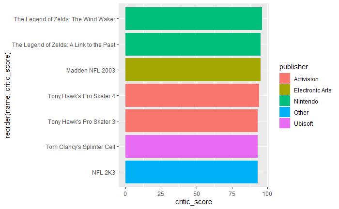

```r
game_sales %>%
  filter(year_of_release == 2002) %>%
  select(name, critic_score, publisher) %>%
  slice_max(critic_score, n = 5) %>%
  ggplot()+
  aes(x = reorder(name, critic_score), y = critic_score, fill = publisher)+
  geom_bar(stat = "identity", position = "dodge") +
  coord_flip()
```

Top rated games by users

```r
game_sales %>%
  select(name, genre, publisher, platform, user_score) %>%
  slice_max(user_score, n = 5)
```

| name | genre | publisher | platform | user_score |
| --- | --- | --- | --- | --- |
| Resident Evil 4 | Action | Capcom | GC | 9.4 |
| Castlevania: Symphony of the Night | Platform | Konami Digital Entertainment | PS | 9.4 |
| Dynasty Warriors 4 | Action | Tecmo Koei | PS2 | 9.3 |
| Dynasty Warriors 3: Xtreme Legends | Action | Tecmo Koei | PS2 | 9.3 |
| NHL 06 | Sports | Electronic Arts | GC | 9.3 |
| Klonoa 2: Dream Champ Tournament | Platform | Other | GBA | 9.3 |
| Jet Grind Radio | Action | Other | GBA | 9.3 |

Plot the top 5 scoring games by users for 2008

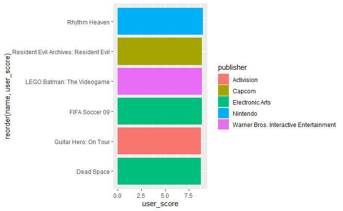

```r
game_sales %>%
  filter(year_of_release == 2008) %>%
  select(name, user_score, publisher) %>%
  slice_max(user_score, n = 5) %>%
  ggplot()+
  aes(x = reorder(name, user_score), y = user_score, fill = publisher)+
  geom_bar(stat = "identity", position = "dodge") +
  coord_flip()
```

Top selling games

```r
game_sales %>%
  select(name, genre, publisher, developer, sales, critic_score, user_score) %>%
  slice_max(sales, n = 10)
```

| name | genre | publisher | developer | sales | critic_score | user_score |
| --- | --- | --- | --- | --- | --- | --- |
| Wii Sports | Sports | Nintendo | Nintendo | 82.53 | 76 | 8.0 |
| Mario Kart Wii | Racing | Nintendo | Nintendo | 35.52 | 82 | 8.3 |
| Wii Sports Resort | Sports | Nintendo | Nintendo | 32.77 | 80 | 8.0 |
| New Super Mario Bros. | Platform | Nintendo | Nintendo | 29.80 | 89 | 8.5 |
| Wii Play | Misc | Nintendo | Nintendo | 28.92 | 58 | 6.6 |
| New Super Mario Bros. Wii | Platform | Nintendo | Nintendo | 28.32 | 87 | 8.4 |
| Mario Kart DS | Racing | Nintendo | Nintendo | 23.21 | 91 | 8.6 |
| Wii Fit | Sports | Nintendo | Nintendo | 22.70 | 80 | 7.7 |
| Wii Fit Plus | Sports | Nintendo | Nintendo | 21.79 | 80 | 7.4 |
| Brain Age: Train Your Brain in Minutes a Day | Misc | Nintendo | Nintendo | 20.15 | 77 | 7.9 |

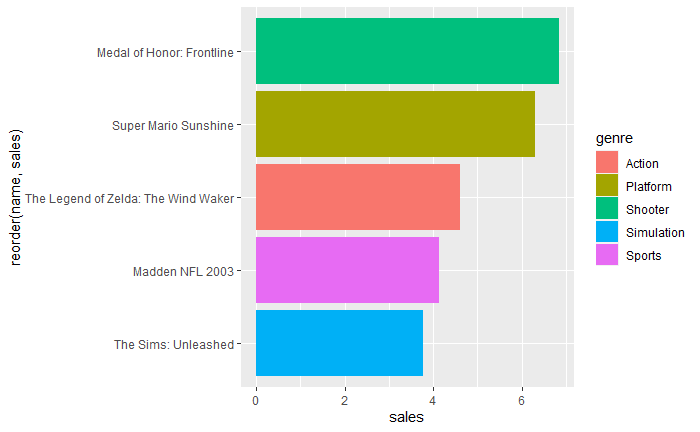

```r
game_sales %>%
  filter(year_of_release == 2002) %>%
  select(name, sales, genre) %>%
  slice_max(sales, n = 5) %>%
  ggplot()+
  aes(x = reorder(name, sales), y = sales, fill = genre)+
  geom_bar(stat = "identity", position = "dodge") +
  coord_flip()
```

Which platform has the most games?

```r
game_sales %>%
  group_by(platform) %>%
  summarise(game_number = n()) %>%
  arrange(desc(game_number))
```

| platform | game_number |
| --- | --- |
| PS2 | 281 |
| X360 | 262 |
| PS3 | 234 |
| XB | 156 |
| Wii | 141 |
| PC | 131 |
| GC | 129 |
| PSP | 96 |
| PS4 | 72 |
| DS | 68 |

[output cut: 6 more lines]

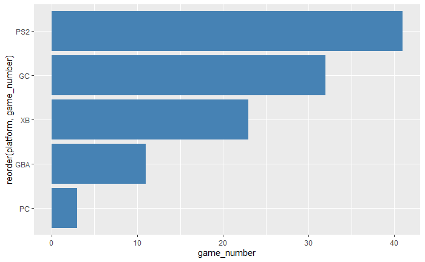

```r
game_sales %>%
  filter(year_of_release == 2002) %>%
  group_by(platform) %>%
  summarise(game_number = n()) %>%
  slice_max(game_number, n = 5) %>%
  ggplot()+
  aes(x = reorder(platform, game_number), y = game_number)+
  geom_bar(stat = "identity", fill = "steelblue") +
  coord_flip()
```

Which publisher has published the most games?

```r
game_sales %>%
  group_by(publisher) %>%
  summarise(game_number = n()) %>%
  arrange(desc(game_number))
```

| publisher | game_number |
| --- | --- |
| Electronic Arts | 648 |
| Ubisoft | 316 |
| Other | 169 |
| Capcom | 103 |
| Activision | 96 |
| Konami Digital Entertainment | 94 |
| Nintendo | 86 |
| Take-Two Interactive | 58 |
| Codemasters | 56 |
| Sony Computer Entertainment | 53 |

[output cut: 3 more lines]

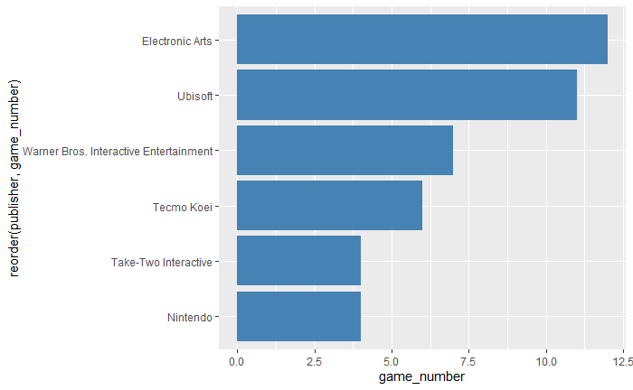

```r
game_sales %>%
  filter(year_of_release == 2015) %>%
  group_by(publisher) %>%
  summarise(game_number = n()) %>%
  slice_max(game_number, n = 5) %>%
  ggplot()+
  aes(x = reorder(publisher, game_number), y = game_number)+
  geom_bar(stat = "identity", position = "dodge", fill = "steelblue") +
  coord_flip()
```

Which developer has developed the most games?

```r
game_sales %>%
  group_by(developer) %>%
  summarise(game_number = n()) %>%
  arrange(desc(game_number))
```

| developer | game_number |
| --- | --- |
| EA | 647 |
| Ubisoft | 308 |
| Capcom | 125 |
| Konami | 95 |
| Omega Force | 69 |
| Nintendo | 68 |
| Visual Concepts | 67 |
| Traveller's Tales | 59 |
| Codemasters | 57 |
| Vicarious Visions | 57 |

[output cut: 6 more lines]

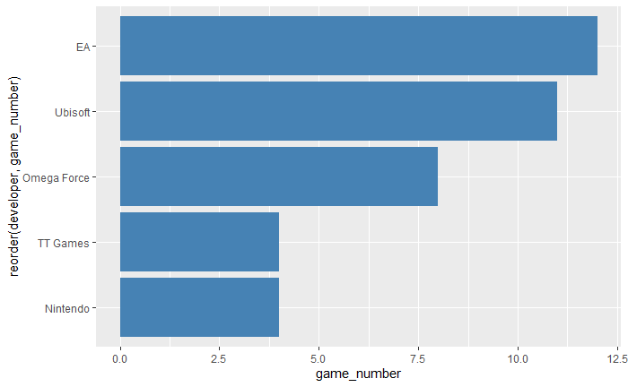

```r
game_sales %>%
  group_by(developer) %>%
  filter(year_of_release == 2015) %>%
  summarise(game_number = n()) %>%
  slice_max(game_number, n = 5) %>%
  ggplot()+
  aes(x = reorder(developer, game_number), y = game_number)+
  geom_bar(stat = "identity", position = "dodge", fill = "steelblue") +
  coord_flip()
```

Which publisher has the highest critic score rating on average?

```r
game_sales %>%
  group_by(publisher) %>%
  summarise(avg_crit_rating = mean(critic_score), avg_user_rating = mean(user_score)) %>%
  arrange(desc(avg_crit_rating))
```

| publisher | avg_crit_rating | avg_user_rating |
| --- | --- | --- |
| Nintendo | 79.58140 | 8.086047 |
| Activision | 78.38542 | 7.257292 |
| Codemasters | 78.10714 | 6.937500 |
| Take-Two Interactive | 77.15517 | 6.579310 |
| Electronic Arts | 75.77006 | 7.112809 |
| Sony Computer Entertainment | 75.13208 | 7.379245 |
| Other | 74.66272 | 7.615385 |
| Capcom | 74.49515 | 7.593204 |
| Warner Bros. Interactive Entertainment | 73.03846 | 7.201923 |
| Konami Digital Entertainment | 72.37234 | 7.201064 |

[output cut: 3 more lines]

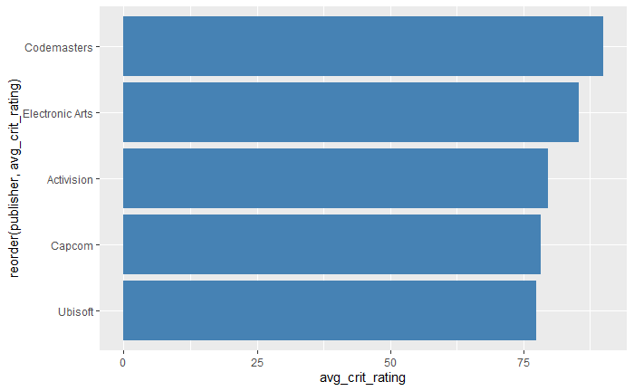

```r
game_sales %>%
  filter(year_of_release == 2000) %>%
  group_by(publisher) %>%
  summarise(avg_crit_rating = mean(critic_score), avg_user_rating = mean(user_score)) %>%
  slice_max(avg_crit_rating, n = 5) %>%
  ggplot()+
  aes(x = reorder(publisher, avg_crit_rating), y = avg_crit_rating)+
  geom_bar(stat = "identity", position = "dodge", fill = "steelblue") +
  coord_flip()
```

Which publisher has the highest user score rating on average?

```r
game_sales %>%
  group_by(publisher) %>%
  summarise(avg_crit_rating = mean(critic_score), avg_user_rating = mean(user_score)) %>%
  arrange(desc(avg_user_rating))
```

| publisher | avg_crit_rating | avg_user_rating |
| --- | --- | --- |
| Nintendo | 79.58140 | 8.086047 |
| Tecmo Koei | 63.27451 | 7.827451 |
| Other | 74.66272 | 7.615385 |
| Capcom | 74.49515 | 7.593204 |
| Midway Games | 68.26829 | 7.478049 |
| Sony Computer Entertainment | 75.13208 | 7.379245 |
| Activision | 78.38542 | 7.257292 |
| Warner Bros. Interactive Entertainment | 73.03846 | 7.201923 |
| Konami Digital Entertainment | 72.37234 | 7.201064 |
| Electronic Arts | 75.77006 | 7.112809 |

[output cut: 3 more lines]

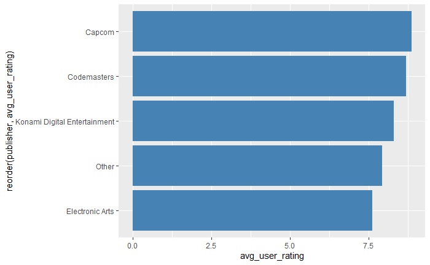

```r
game_sales %>%
  filter(year_of_release == 2000) %>%
  group_by(publisher) %>%
  summarise(avg_crit_rating = mean(critic_score), avg_user_rating = mean(user_score)) %>%
  slice_max(avg_user_rating, n = 5) %>%
  ggplot()+
  aes(x = reorder(publisher, avg_user_rating), y = avg_user_rating)+
  geom_bar(stat = "identity", position = "dodge", fill = "steelblue") +
  coord_flip()
```

Which developer has the highest critic score rating on average?

```r
game_sales %>%
  filter(year_of_release == 2000) %>%
  group_by(developer) %>%
  summarise(avg_crit_rating = mean(critic_score), avg_user_rating = mean(user_score)) %>%
  arrange(desc(avg_crit_rating))
```

| developer | avg_crit_rating | avg_user_rating |
| --- | --- | --- |
| Neversoft Entertainment | 92.50000 | 8.350 |
| Codemasters | 90.00000 | 8.700 |
| Maxis | 87.00000 | 7.250 |
| EA | 85.00000 | 7.725 |
| Namco | 79.50000 | 7.725 |
| Ubisoft | 77.50000 | 7.600 |
| Konami | 73.33333 | 8.300 |
| Capcom | 71.50000 | 8.450 |
| Omega Force | 70.50000 | 8.250 |
| Traveller's Tales | 54.00000 | 5.300 |

[output cut: 1 more lines]

Which developer has the highest user score rating on average?

```r
game_sales %>%
  filter(year_of_release == 2000) %>%
  group_by(developer) %>%
  summarise(avg_crit_rating = mean(critic_score), avg_user_rating = mean(user_score)) %>%
  arrange(desc(avg_user_rating))
```

| developer | avg_crit_rating | avg_user_rating |
| --- | --- | --- |
| Codemasters | 90.00000 | 8.700 |
| Capcom | 71.50000 | 8.450 |
| Neversoft Entertainment | 92.50000 | 8.350 |
| Konami | 73.33333 | 8.300 |
| Omega Force | 70.50000 | 8.250 |
| EA | 85.00000 | 7.725 |
| Namco | 79.50000 | 7.725 |
| Ubisoft | 77.50000 | 7.600 |
| Maxis | 87.00000 | 7.250 |
| Traveller's Tales | 54.00000 | 5.300 |

[output cut: 1 more lines]

View number games released each year

```r
game_sales %>%
  group_by(year_of_release) %>%
  summarise(game_number = n(), sales_number = sum(sales))
```

| year_of_release | game_number | sales_number |
| --- | --- | --- |
| 1988 | 1 | 0.03 |
| 1996 | 3 | 10.93 |
| 1997 | 2 | 2.16 |
| 1998 | 4 | 14.69 |
| 1999 | 3 | 7.40 |
| 2000 | 32 | 33.10 |
| 2001 | 61 | 77.88 |
| 2002 | 110 | 101.43 |
| 2003 | 120 | 95.08 |
| 2004 | 132 | 104.87 |

[output cut: 12 more lines]

Plot histogram of game releases

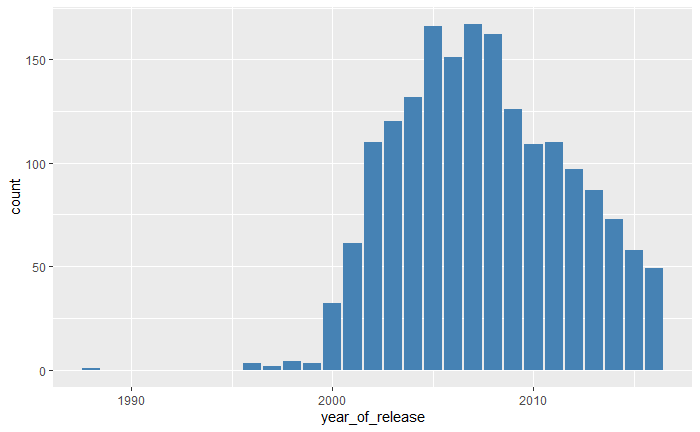

```r
game_sales %>%
  ggplot() +
  aes(x = year_of_release) +
  geom_bar(fill = "steelblue")
```

Game sales per year

```r
game_sales %>%
  group_by(year_of_release, genre) %>%
  summarise(sales_number = sum(sales))
```

| year_of_release | genre | sales_number |
| --- | --- | --- |
| 1988 | Simulation | 0.03 |
| 1996 | Action | 5.05 |
| 1996 | Fighting | 5.74 |
| 1996 | Puzzle | 0.14 |
| 1997 | Platform | 1.27 |
| 1997 | Simulation | 0.89 |
| 1998 | Action | 5.82 |
| 1998 | Fighting | 8.19 |
| 1998 | Role-Playing | 0.68 |
| 1999 | Racing | 2.31 |

[output cut: 179 more lines]

Plot histogram of game sales

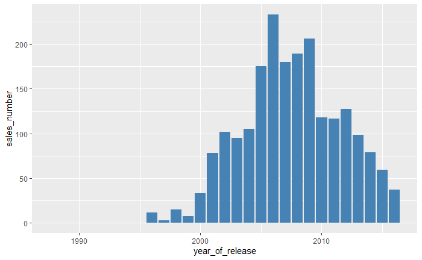

```r
game_sales %>%
  group_by(year_of_release) %>%
  summarise(sales_number = sum(sales)) %>%
  ggplot() +
  aes(x = year_of_release, y = sales_number) +
  geom_bar(stat = "identity", fill = "steelblue")
```

Check correlation btw critic score and user score

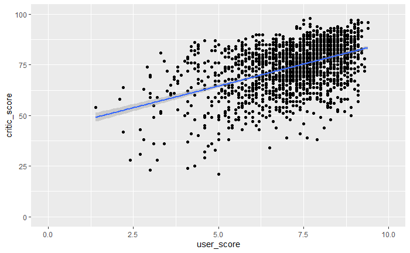

```r
game_sales %>%
  ggplot(aes(x = user_score, y = critic_score)) +
  geom_point() +
  geom_smooth(method = "lm", show.legend = FALSE) +
  xlim(0, 10) +
  ylim(0, 100)
```

Correlation between releases and sales

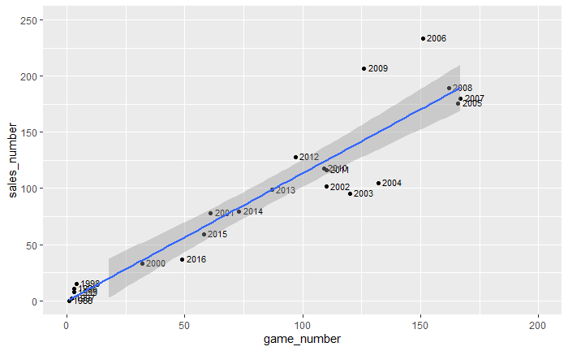

```r
game_sales %>%
  group_by(year_of_release) %>%
  summarise(game_number = n(), sales_number = sum(sales)) %>%
  ggplot(aes(x = game_number, y = sales_number)) +
  geom_point()  +
  geom_text(
    aes(label = year_of_release),
    size = 3,
    nudge_x = 6,
    nudge_y = 1,
  ) +
  geom_smooth(method = "lm", show.legend = FALSE)+
  xlim(0, 200) +
  ylim(0, 250)
```

```r
NA
```